# Medical Appointment No Shows

### Q1. What is the percentage of patients who didn't show up for their appointments?

```python
no_showed = ((df.no_show.value_counts()[1]/df.no_show.count())*100).round(2)
print("{} patients didn't showed up for their appointments.".format(no_showed))
```

```
20.19 patients didn't showed up for their appointments.
```

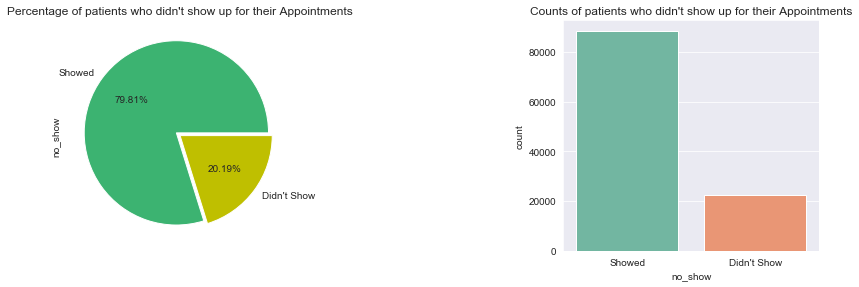

```python
# Subplots
figs, axes = plt.subplots(1,2)
plt.subplots_adjust(left=0.125, bottom=0.1, right=1.9, top=0.9, wspace=1, hspace=1)
# Pie Chart
df.no_show.value_counts().plot(kind='pie', autopct='%.2f%%', explode=(0.05,0),
                               labels=['Showed', 'Didn\'t Show'], colors=['mediumseagreen','y'], ax=axes[0])
axes[0].set_title("Percentage of patients who didn't show up for their Appointments")
# Count Plot
sns.countplot(df['no_show'], ax=axes[1], palette='Set2')
axes[1].set_xticklabels(['Showed','Didn\'t Show'])
axes[1].set_title("Counts of patients who didn't show up for their Appointments")
plt.show()
```

### Q2. What is the ratio of categorical characteristics of the dataset and the no_show characteristic?

```
In order to answer this question we will find the ratio against each of the following categorical characteristics:
    1. Gender
    2. Scholarship
    3. Hypertension
    4. Diabetes
    5. Alcoholism
    6. Handicap

Let's begin with:
```

- **Gender**

```python
# Define a function to plot ratio of categorical characteristics of the dataset and the no_show characteristic
def cat_plots(col,plabel,ptitle,pglabel,pgtitle):
    # Subplots
    figs, axes = plt.subplots(1,2, figsize=(8,8))
    plt.subplots_adjust(left=0.12, right=1.7, wspace=0.5, hspace=0.5)
    # Pie Chart
    df[col].value_counts().plot(kind='pie', autopct='%.2f%%', explode=(0.05,0),
                                labels=plabel, colors=['mediumseagreen','y'], ax=axes[0])
    axes[0].set_title(ptitle)
    # Pie Chart: Categorical characteristics and No_Show characteristic
    df[col].groupby(df['no_show']).value_counts().plot(kind='pie', autopct='%.2f%%', explode=(0.05,0.05,0,0),
                                   labels=pglabel, colors=['#228B22','#2E8B57','#F0E68C','#BDB76B'], ax=axes[1])
    axes[1].set_title(pgtitle)
    plt.show()

def count_plots(col, clabel, ctitle):
    # Count Plot
    plt.figure(figsize=(7,5))
    sns.countplot(df[col], hue=df['no_show'], palette='Set2')
    plt.xticks(ticks=[0,1], labels=clabel)
    plt.title(ctitle)
    plt.show()
```

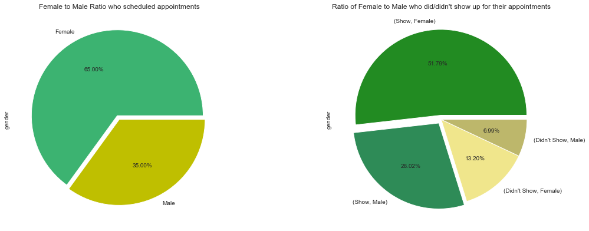

```python
# Ratio of Gender against no show characterisic
cat_plots('gender', ['Female', 'Male'], "Female to Male Ratio who scheduled appointments",
          ["(Show, Female)", "(Show, Male)","(Didn't Show, Female)", "(Didn't Show, Male)"],
          "Ratio of Female to Male who did/didn't show up for their appointments")
```

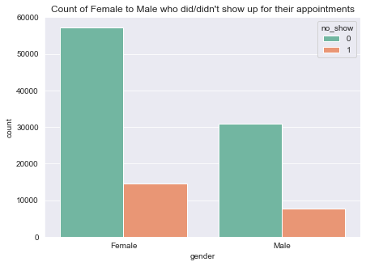

```python
# Count plot representing frequency of Gender over no show characteristic
count_plots('gender', ['Female', 'Male'], "Count of Female to Male who did/didn't show up for their appointments")
```

> From the above charts, it can be seen clearly that in the given dataset of 100K records, 65.00% patients are female while 35.00% patients are male. Gender donot have an overall impact on the dataset as the distribution is skewed towards women. Also, the females who didn't show up are approximately doubled (13.20%) in comparision to males (6.99%) who didn't show up.
- **Scholarship**

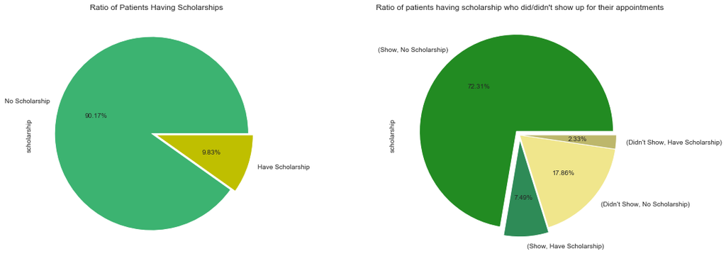

```python
# Ratio of Scholarship against no show characterisic
cat_plots('scholarship', ['No Scholarship', 'Have Scholarship'], "Ratio of Patients Having Scholarships",
          ["(Show, No Scholarship)", "(Show, Have Scholarship)",
           "(Didn't Show, No Scholarship)", "(Didn't Show, Have Scholarship)"],
          "Ratio of patients having scholarship who did/didn't show up for their appointments")
```